# Project: Understanding Why patients show up for appointment

- Introduction
- Data Wrangling
- Exploratory Data Analysis
- Conclusions

## Introduction

In this project, we hope to understand the reasons why a patient will either show up or fail to show up after booking an appointment with a doctor. We will be adopting the **KaggleV2-May-2016** dataset to achieve this objective. This dataset collects information from 100k medical appointments in Brazil and is focused on the question of whether or not patients show up for their appointment.

Our data of interest has 14 features and the data we want to predict (**No Show**) is a categorical variable, which has two outome: Yes or No. Yes in this case means that the patient did not show up, while No means that the patient showed up. Liste below are the features in the dataset.

1. PatientId
2. AppointmentID
3. Gender
4. ScheduledDay
5. AppointmentDay
6. Age
7. Neighbourhood
8. Scholarship
9. Hipertension
10. Diabetes
11. Alcoholism
12. Handcap
13. SMS_received
14. No-show

We try to answer this question by looking at the relationship between the No-show feature in our dataset as against these variables.

1. Gender: A patient can be male or female
2. Scholarship: This implies that a patient can be enrolled or not enrolled in Brasilian welfare program
3. Ailments: In this dataset, we treat features like Handicap, Hipertension, diabetes, Alcoholism as ailment. We then try to understand the impact of this feature on the outcome variable.
4. Test Messages: If a patient received test messages or not.

Given these variables, we hope to answer the above question by asking these sets of question:

1. Does a patient's gender determine if he or she will show up for an appointment?
2. Does Scholarship increase the the rate at which people will show up for appointment?
3. How does ailment such as Diabetes, Alcoholism, impact if a patient will show up for appointment or not?
4. What role does information play in patients showing up for appointments?

```python
%matplotlib inline
import pandas as pd
import numpy as np
import matplotlib.pyplot as plt
import seaborn as sb
from pandas import read_csv
from pandas import set_option
```

## Data Wrangling

### General Properties

```python
data = pd.read_csv('C:/Users/user/Downloads/archive (2)/KaggleV2-May-2016.csv')
data.head()
```

|  | PatientId | AppointmentID | Gender | ScheduledDay | AppointmentDay | Age | Neighbourhood | Scholarship | Hipertension | Diabetes | Alcoholism | Handcap | SMS_received | No-show |
| --- | --- | --- | --- | --- | --- | --- | --- | --- | --- | --- | --- | --- | --- | --- |
| 0 | 2.987250e+13 | 5642903 | F | 2016-04-29T18:38:08Z | 2016-04-29T00:00:00Z | 62 | JARDIM DA PENHA | 0 | 1 | 0 | 0 | 0 | 0 | No |
| 1 | 5.589978e+14 | 5642503 | M | 2016-04-29T16:08:27Z | 2016-04-29T00:00:00Z | 56 | JARDIM DA PENHA | 0 | 0 | 0 | 0 | 0 | 0 | No |
| 2 | 4.262962e+12 | 5642549 | F | 2016-04-29T16:19:04Z | 2016-04-29T00:00:00Z | 62 | MATA DA PRAIA | 0 | 0 | 0 | 0 | 0 | 0 | No |
| 3 | 8.679512e+11 | 5642828 | F | 2016-04-29T17:29:31Z | 2016-04-29T00:00:00Z | 8 | PONTAL DE CAMBURI | 0 | 0 | 0 | 0 | 0 | 0 | No |
| 4 | 8.841186e+12 | 5642494 | F | 2016-04-29T16:07:23Z | 2016-04-29T00:00:00Z | 56 | JARDIM DA PENHA | 0 | 1 | 1 | 0 | 0 | 0 | No |

```python
data.shape
```

```
(110527, 14)
```

Just like we stated earlier, the data we are interested in analyzing has 14 features and a sample size of 110527

```python
data.info()
```

```
<class 'pandas.core.frame.DataFrame'>
RangeIndex: 110527 entries, 0 to 110526
Data columns (total 14 columns):
 #   Column          Non-Null Count   Dtype
---  ------          --------------   -----
 0   PatientId       110527 non-null  float64
 1   AppointmentID   110527 non-null  int64
 2   Gender          110527 non-null  object
 3   ScheduledDay    110527 non-null  object
 4   AppointmentDay  110527 non-null  object
 5   Age             110527 non-null  int64
 6   Neighbourhood   110527 non-null  object
 7   Scholarship     110527 non-null  int64
 8   Hipertension    110527 non-null  int64
 9   Diabetes        110527 non-null  int64
 10  Alcoholism      110527 non-null  int64
 11  Handcap         110527 non-null  int64
 12  SMS_received    110527 non-null  int64
 13  No-show         110527 non-null  object
dtypes: float64(1), int64(8), object(5)
memory usage: 11.8+ MB
```

```python
data.isna().sum()
```

```
PatientId         0
AppointmentID     0
Gender            0
ScheduledDay      0
AppointmentDay    0
Age               0
Neighbourhood     0
Scholarship       0
Hipertension      0
Diabetes          0
Alcoholism        0
Handcap           0
SMS_received      0
No-show           0
dtype: int64
```

The dataset for this particular project is very clean given the fact that all the columns in our dataset does not have a missing value. We are going to drop some columns in this dataset since some of them will be irrelevent to our analysis. This include:

1. PatientId
2. AppointmentID
3. ScheduledDay
4. AppointmentDay
5. Neighbourhood

```python
data.drop(['PatientId','AppointmentID', 'ScheduledDay', 'AppointmentDay', 'Neighbourhood'], axis = 1, inplace = True)
```

```python
data.shape
```

```
(110527, 9)
```

After dropping the columns listed above, note that the number of columns has reduced from 14 to 9.

## Exploratory Data Analysis

```python
data.describe()
```

|  | Age | Scholarship | Hipertension | Diabetes | Alcoholism | Handcap | SMS_received |
| --- | --- | --- | --- | --- | --- | --- | --- |
| count | 110527.000000 | 110527.000000 | 110527.000000 | 110527.000000 | 110527.000000 | 110527.000000 | 110527.000000 |
| mean | 37.088874 | 0.098266 | 0.197246 | 0.071865 | 0.030400 | 0.022248 | 0.321026 |
| std | 23.110205 | 0.297675 | 0.397921 | 0.258265 | 0.171686 | 0.161543 | 0.466873 |
| min | -1.000000 | 0.000000 | 0.000000 | 0.000000 | 0.000000 | 0.000000 | 0.000000 |
| 25% | 18.000000 | 0.000000 | 0.000000 | 0.000000 | 0.000000 | 0.000000 | 0.000000 |
| 50% | 37.000000 | 0.000000 | 0.000000 | 0.000000 | 0.000000 | 0.000000 | 0.000000 |
| 75% | 55.000000 | 0.000000 | 0.000000 | 0.000000 | 0.000000 | 0.000000 | 1.000000 |
| max | 115.000000 | 1.000000 | 1.000000 | 1.000000 | 1.000000 | 4.000000 | 1.000000 |

The median age of our dataset is 37 and the age distribution is skewed to the righ which means that majority of the patients that booked an appointment fall within the age bracket of 50 and below. The maximum age of the patient sampled is 115, while the minimum age is -1.

They were more patients without scholarships compared to patients with scholarships. The number of patients without scholarship stood at 99666, while the number of patients with scholarship stood at 10861. Majoeity of the patients don't have Hipertension, Diabetes, alcoholism, and handicap. A better picture of the features in our dataset is shown below.

Do note that 0 is False while 1 is True

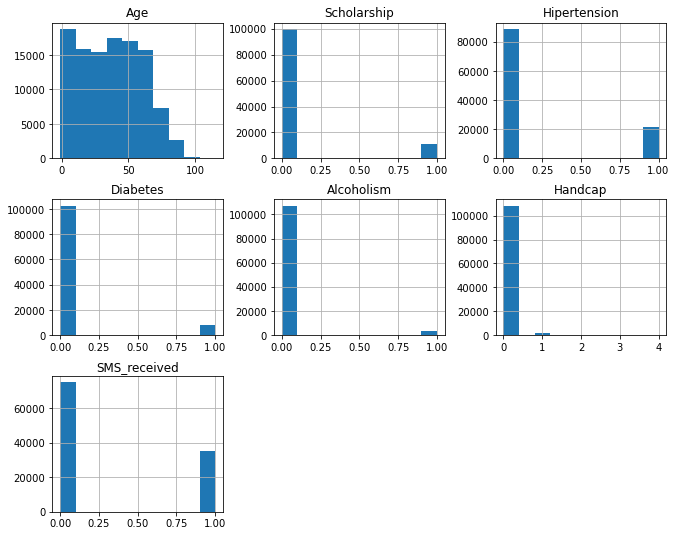

```python
data.hist(figsize=(11,9));
```

```python
data.rename(columns={'No-show':'No_show'}, inplace=True)
```

```python
data.info()
```

[output not shown]

```python
data['No-show'].value_counts()
```

[output not shown]

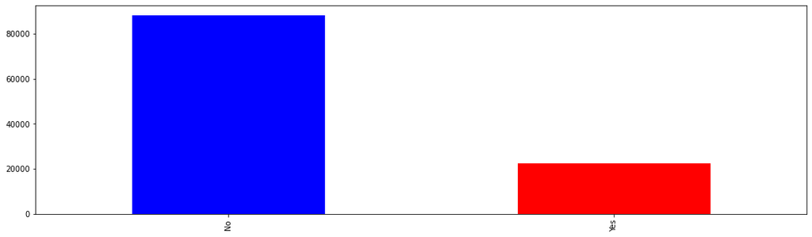

```python
data['No-show'].value_counts().plot(kind='bar', color=['blue', 'red'], figsize=(18,5));
```

Out of the 110,527 patients interviwed, majority of the patients came for the appointment they booked. The number of patients that showed up for the appointment stands at 88,208, while the number of patients that did not show up for appointment stood at 22319.

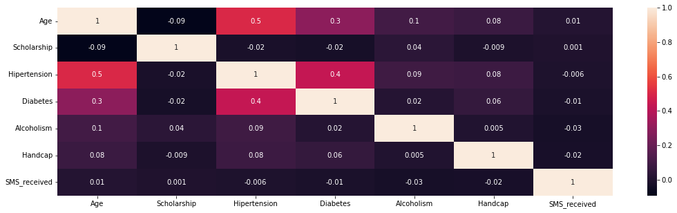

```python
set_option('display.width', 100)

plt.figure(figsize=(18,5))

sb.heatmap(data.corr(), annot = True, fmt='.1g');
```

Although, our discussion is not centered on predicting patients that will show up or not. However, it is important to get a picture of the correlation between these variables to avoid the pitfall of double counting. In other words, two variable having the same predictive effect on the outcome variable.

From the heatmap displayed, there is no strong correlation between the variables as majority of the result are below 0.5.

### Question 1: Does Gender play a role in the number of patient that show up for appointment

To begin our analysis, we looked at the number of male and female in our data set. Using .value_counts() we discovered that there are more females than male in our data set. The result is shown below

```python
# Use this, and more code cells, to explore your data. Don't forget to add
#   Markdown cells to document your observations and findings.
data.Gender.value_counts()
```

```
F    71840
M    38687
Name: Gender, dtype: int64
```

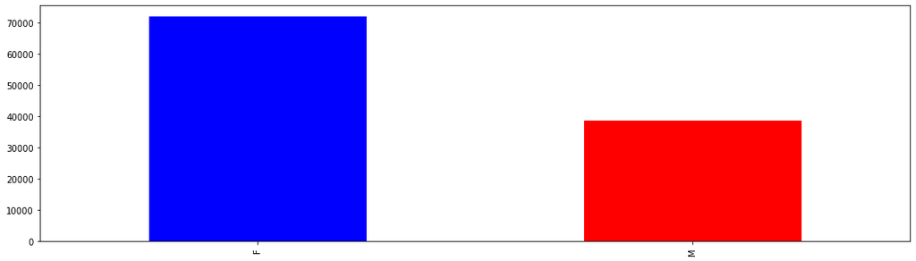

```python
data.Gender.value_counts().plot(kind='bar', color=['blue', 'red'], figsize=(18,5));
```

Next, we filter the data to show only rows with male and female, with the aim of explaining the role gender in whether a patient will show up for appointment or not.

```python
Male = data[data['Gender'] == 'M']
Female = data[data['Gender'] == 'F']
```

The variable M represents all rows for which gender is equal to Male, while the variable F represent all rows for which gender is equal to Female. Next, we look at the number of males and females that did show or did not show up for appointment.

```python
data.rename(columns={'No-show':'No_Show'}, inplace=True)
```

```python
data.info()
```

[output not shown]

```python
Male.iloc[:, 8].value_counts()
```

```
No     30962
Yes     7725
Name: No-show, dtype: int64
```

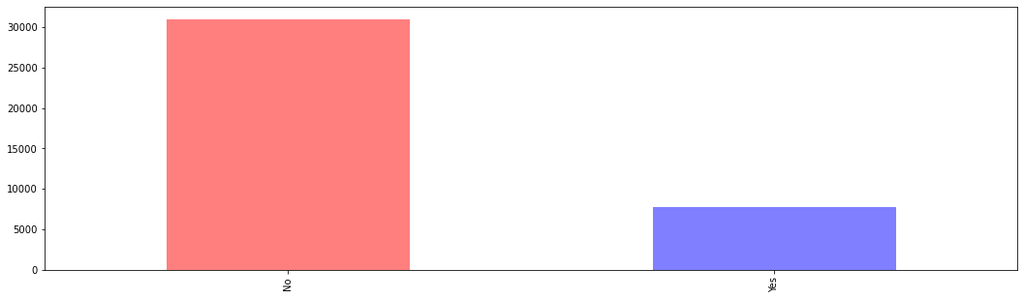

```python
Male.iloc[:, 8].value_counts().plot(kind='bar', color=['red', 'blue'], alpha=0.5, figsize=(18,5))
```

```python
Female.iloc[:, 8].value_counts()
```

```
No     57246
Yes    14594
Name: No-show, dtype: int64
```

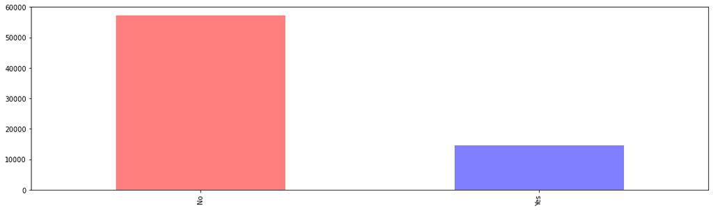

```python
Female.iloc[:, 8].value_counts().plot(kind='bar', color=['red', 'blue'], alpha=0.5, figsize=(18,5))
```

Although more women show up for appointment than men, it will be wrong to assume that if a patient is female, then, the probaility that they will show up for appointment is high compared to a man. This is as a result of the high number of females than males. A good place to start will be to look at the percentage of males and females that show up as a percentage of the total male and female that booked an appointment.

Given the above criteria it can be concluded that gender does not determine if a patient will show up for an appointment or not. This is as a result of the fact that the percentage of male and female that show up for appointment as a percentage of the total male and female thar booked an appointment is approximately 80 percent.

### Question 2: Does being enrolled in the Brazillian welfare Program increase the possibility that a patient will show up for appointment?

Similar to the first question we explored, we begin by getting an idea of the number of patients with or with scholarship. The value **1** implies that the patient is part of the welfare system. On the other hand, **0** means that the patient is not enrolled in Brazillian welfare program.

```python
data.Scholarship.value_counts()
```

```
0    99666
1    10861
Name: Scholarship, dtype: int64
```

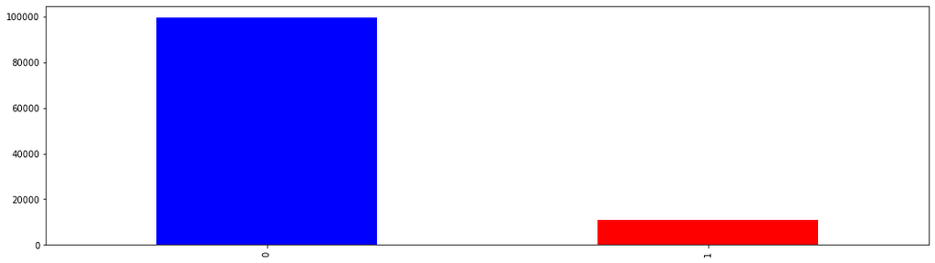

```python
data.Scholarship.value_counts().plot(kind='bar', color=['blue', 'red'], figsize=(18,5));
```

From the result above, the number of patient enrolled in Brazil's Welfare program is small compared to patient that is not enrolled in Brazil's welfare system.

```python
Schol = data[data['Scholarship'] == True]
NoSchol = data[data['Scholarship'] == False]
```

The code above filters our dataset to reflect rows for which patients are either enrolled or not enrolled in Brazil's welfare system.

```python
Schol.iloc[:, 8].value_counts()
```

```
No     8283
Yes    2578
Name: No-show, dtype: int64
```

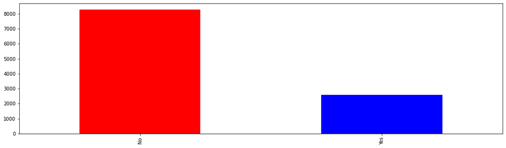

```python
Schol.iloc[:, 8].value_counts().plot(kind='bar', color=['red', 'blue'], figsize=(18,5))
```

```python
NoSchol.iloc[:, 8].value_counts()
```

```
No     79925
Yes    19741
Name: No-show, dtype: int64
```

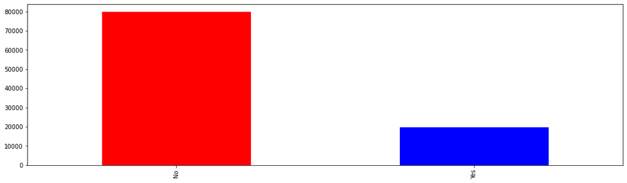

```python
NoSchol.iloc[:, 8].value_counts().plot(kind='bar', color=['red', 'blue'], figsize=(18,5));
```

In both cases (Scholarship or No Scholarship), it was discovered that the number of patient that showed up for appointment is high both cases. Rather than focusing on the absolute term, let's look at patient with Scholarship or No-Scholarship that showed up or not as a percentage of the total patients.

Based on the criteria above, it was discovered that in terms of patient with Scholarship the number of patient that showed up as a percentage of the total number in this category stood at 76.2 percent. On the other hand, for patients without scholarship, the figure stood at 80 percent.

Again, being a part of a welfare system does not predict that a customer will show up for an appointment or not.

### Question 3: What role does having an ailment has on whether a customer will show up for an appointment or not

In this case, we try to understand if a patient that is handicap, or addicted to alcohol have an impact on him or her showing up or not. We will also consider variables like hipertension and diabetes.

```python
data.head()
```

[output not shown]

```python
Hyp = data[data['Hipertension'] == 1]
NoHyp = data[data['Hipertension'] != 1]
```

```python
Hyp['Hipertension'].value_counts()
```

```
1    21801
Name: Hipertension, dtype: int64
```

```python
NoHyp['Hipertension'].value_counts()
```

```
0    88726
Name: Hipertension, dtype: int64
```

The total number of patients with Hipertension is 21801 as against 88726 which is the number of patients that does not have hipertension.

```python
Hyp.iloc[:, 8].value_counts()
```

```
No     18029
Yes     3772
Name: No-show, dtype: int64
```

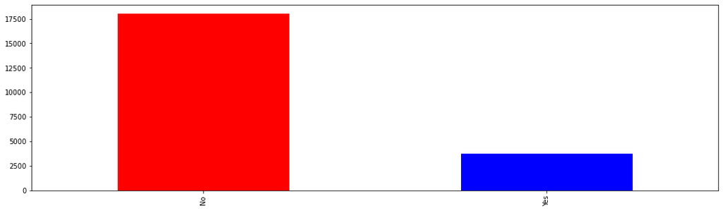

```python
Hyp.iloc[:, 8].value_counts().plot(kind='bar', color=['red', 'blue'], figsize=(18,5));
```

```python
NoHyp.iloc[:, 8].value_counts()
```

```
No     70179
Yes    18547
Name: No-show, dtype: int64
```

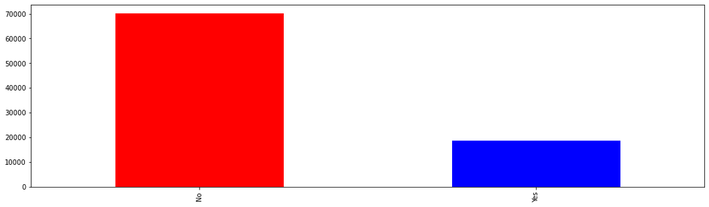

```python
NoHyp.iloc[:, 8].value_counts().plot(kind='bar', color=['red', 'blue'], figsize=(18,5));
```

In the case of both patients with or without hipertension, the number of patients that showed up for appointments is high. An important result from this finding stems from the fact that the percentage of patients with hipertension that showed up for appointment is slightly higher when compared to the patients without hipertension. The probaility that a patient under the hipertension will show up for an appointment is 0.827 compared to 0.791.

```python
Hypgroup = Hyp.groupby(['Diabetes', 'Alcoholism', 'Handcap'])
Hypgroup['No-show'].value_counts()
```

```
Diabetes  Alcoholism  Handcap  No-show
0         0           0        No         11338
                               Yes         2325
                      1        No           449
                               Yes           92
                      2        No            24
                               Yes           15
                      3        Yes            1
          1           0        No           845
                               Yes          197
                      1        No            25
                               Yes            1
                      2        No             3
1         0           0        No          4841
                               Yes         1044
                      1        No           260
                               Yes           44
                      2        No            34
                               Yes            7
          1           0        No           201
                               Yes           42
                      1        No             9
                               Yes            3
                      2        Yes            1
Name: No-show, dtype: int64
```

```python
NoHypgroup = NoHyp.groupby(['Diabetes', 'Alcoholism', 'Handcap'])
NoHypgroup['No-show'].value_counts()
```

```
Diabetes  Alcoholism  Handcap  No-show
0         0           0        No         66512
                               Yes        17603
                      1        No           869
                               Yes          219
                      2        No            84
                               Yes           13
                      3        No             7
                               Yes            2
                      4        No             2
                               Yes            1
          1           0        No          1506
                               Yes          416
                      1        No            28
                               Yes            3
                      2        Yes            1
                      3        No             3
1         0           0        No          1068
                               Yes          273
                      1        No            36
                               Yes            3
                      2        No             1
          1           0        No            63
                               Yes           12
                      1        Yes            1
Name: No-show, dtype: int64
```

From our findings above, the probabillity that a patient will show up when they when they have at least one of these ailment is high. This is event in both cases above. The first code we wrote look at the number of patients with hipertension grouped by Diabetes, Alcoholism and Handicap. The second code describes the number of patients without hipertension grouped by Diabetes, Alcoholism, and Handicap. When one of these ailment is present in a patient, the probability that they will show up for an appointment is high.

### Question 4: Does SMS Message play a role in determining if a patient will show up for appointment?

We expect that people who get reminded through a text message wil show up for appointment. Thus, we are postulating that the more patient receive text messages, the more likely a patient will show up for appointments. We explore this question below.

```python
SMS = data[data['SMS_received'] == 1]
NSMS = data[data['SMS_received'] == 0]
```

```python
SMS['SMS_received'].value_counts()
```

```
1    35482
Name: SMS_received, dtype: int64
```

```python
NSMS['SMS_received'].value_counts()
```

```
0    75045
Name: SMS_received, dtype: int64
```

According to the above result, the number of patient that receives SMS is 35482, while patients that do not rceive SMS stand at 75045. Giving this finding, we would like to know if patients that showed up for appointment comes from the class of patients that receives SMS messages.

```python
SMS.iloc[:, 8].value_counts()
```

```
No     25698
Yes     9784
Name: No-show, dtype: int64
```

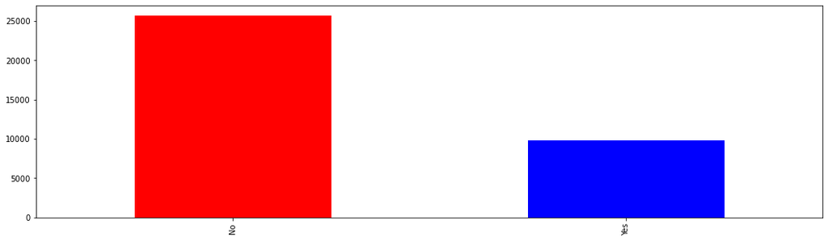

```python
SMS.iloc[:, 8].value_counts().plot(kind='bar', color=['red', 'blue'], figsize=(18,5));
```

```python
NSMS.iloc[:, 8].value_counts()
```

```
No     62510
Yes    12535
Name: No-show, dtype: int64
```

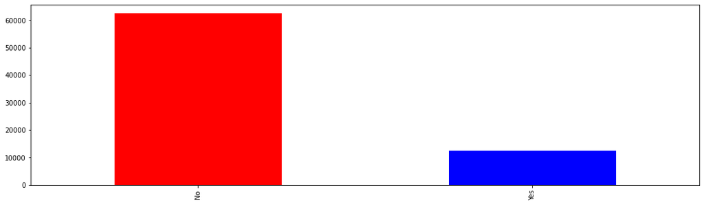

```python
NSMS.iloc[:, 8].value_counts().plot(kind='bar', color=['red', 'blue'], figsize=(18,5));
```

In the case of patients that received SMS messages, the number of patients that showed up for appointment as a percentage of the total number of patients in this category stand at 72.4 percent. On the other hand, the number of patients that showed up for appointments in the case of customers that did not receive SMS messages stood at 83.3 percent.

## Conclusions

At the start of this project, we set out with the objective of understanding what determines if a patient will show up for an apppointment or not. We considered variable like gender, ailments(diabetes et al), scholarship, and text messages. According to our findings, there is no clear picture as per whether any of the variables we considered will cause patients to show up for an appointment or not. Given the set of features in the dataset, we tried to understand how certain features will end up making a customer show up for an appointment. Thus, we asked the following questions:

1. Does a patient's gender determine if he or she will show up for an appointment?
2. Does Scholarship increase the rate at which people will show up for appointment
3. How does ailment such as Diabetes, Alcoholism, impact if a patient will show up for appointment or not
4. What role does information play in patients showing up for appointments

**The approach in solving the problem** To answer these questions, we filtered the data in such a way that we had two set of variables for a particular question. For instance, in the aspect of gender, we filtered the data for rows with males and did the same for female. We then selected the No-Show column for both variable to reflect the number of males and females that showed up or did not show up for their appointment. This was repeated for other variables like Scholarship, ailments, SMS messages.

Although we followed the same approach in answering the questions highlighted above, we did something different with the third question. We filtered the data to reflect rows for which patients has hypertension or not. We then group by diabetes, alcoholism, handicap to know the number of customers that have hypertension and also fall under one of these categories. Similarly, we use the same approach to know the patients without hypertension that falls under one of these categories.

**Absence of data Wrangling** Our data of interest was in the best possible state, so there was no need to clean the data as there was missing number in our data. For each of the questions we tried to answer, we created a bar plot to show the number of people that showed up or failed to show up for a particular feature. Using SMS Messages for instance, we filtered the data to reflect the number of patients that received SMS and the number of people that did not receive SMS.

The idea was to understand if there was a correlation between the number of people that showed up for an appointment as against people that received messages. We then use bar plot to understand the number of people that received SMS and showed up for appointment and people who received SMS but failed to show up for appointment. We did the same thing for people that did not received SMS but show up for the appointment as against those that did not show up.

The bar plot showed that in both cases (people that received or did not receive SMS), the number of people that showed up for appointment was high compared to people who did not show up for appointment. We also adopted heatmaps to show the correlation between variables as well as summary statistics to get a full understanding of the data in our data set.

## References

Not available